# DESeq2

BBC, Analyst: Robert Fillinger

February 24, 2025

```r
# this chunk is just to keep the _files directory even when we turn off cacheing
```

```r
# save start time for script
start_tm <- Sys.time()
start_tm
```

```
## [1] "2025-02-24 12:36:21 EST"
```

```r
outdir <- file.path("deseq2_out_files", params$comparison_name)

dir.create(outdir, recursive=TRUE)
```

# 1 **Analysis**

### 1.0.1 **Load packages**

```r
library(dplyr)
```

```r
library(stringr)
library(ggplot2)
library(readr)
library(ggrepel)
library(ComplexHeatmap)
library(DESeq2)
```

### 1.0.2 **Set up your DESeq object**

```r
se <- readRDS(paste0("../../", params$se_obj))

# subset se to just samples in this comparison (relevant esp if variance is diff between groups)
se <- se[, colData(se)$group %in% c(params$group_test, params$group_reference)]

# factor the group column to make sure the reference group is the first level
se$group <- factor(se$group, levels=c(params$group_reference, params$group_test))
```

Let’s take a look to see what assays are stored in the SummarizedExperiment object. Note that DESeq2 assumes the first assay is the raw counts.

```r
assayNames(se)
```

```
## [1] "counts" "tpms"   "vst"
```

```r
stopifnot(assayNames(se)[1] == "counts")
```

To print more information about this SummarizedExperiment object, you can just type its name.

```r
se
```

```
## class: SummarizedExperiment
## dim: 55471 7
## metadata(0):
## assays(3): counts tpms vst
## rownames(55471): ENSMUSG00000102693.1 ENSMUSG00000064842.1 ...
##   ENSMUSG00000095019.1 ENSMUSG00000095041.7
## rowData names(5): Symbol Uniq_syms entrez Gene_name alias
## colnames(7): NTC2 NTC3 ... sgUgcg2 sgUgcg5
## colData names(3): sample group RG
```

The counts and the meta data need to be stored inside a special DESeq2 object called a ‘DESeqDataSet’. Here, we also specify that each gene will be fit with a model design of ‘~ group’.

```r
dds <- DESeqDataSet(se, design = ~ group)
```

### 1.0.3 **Remove genes with low/no expression**

We cannot do meaningful analyses of genes with very low counts. This will speed up the analysis.

```r
# prefilter genes, keeping only genes with 10 or more total read counts across samples
keep <- rowSums(counts(dds)) >= 10

message(str_glue("Keeping {sum(keep)} genes."))
```

```
## Keeping 20969 genes.
```

```r
dds <- dds[keep, ]
```

### 1.0.4 **Different normalization approaches for different biases**

[Types of biases in RNA-seq](https://vanandelinstitute-my.sharepoint.com/:b:/g/personal/kin_lau_vai_org/EcruvwL-OrBIvCzXZ7HMPlcBo65fu0pucrivMmCwzM98dA?e=yCkfTa)

### 1.0.5 **Run the DE workflow**

The DESeq function is a convenience function from DESeq2 that estimates size factors (normalization) and fits negative binomial GLMs.

```r
dds <- DESeq(dds)
message(paste0("Coefficient names are: ", paste(resultsNames(dds), collapse = " ")))
```

```
## Coefficient names are: Intercept group_ko_vs_ctrl
```

After the models are fitted, we can test specific pairs of groups for differential expression. For DESeq2, it is recommended to provide the significance cutoff that you wish to use as it affects the multiple testing correction procedure (see [docs](https://www.rdocumentation.org/packages/DESeq2/versions/1.12.3/topics/results)).

```r
contrast <- c("group", params$group_test, params$group_reference)
fdr_cutoff <- params$fdr_cutoff

res <- results(dds, contrast=contrast, alpha=fdr_cutoff)
res <- res[order(res$pvalue), ]
```

### 1.0.6 **Summarize DE results**

```r
df <- as.data.frame(res)
data.frame(
  UP=sum(df$padj <= fdr_cutoff & df$log2FoldChange > 0, na.rm = TRUE),
  DWN=sum(df$padj <= fdr_cutoff & df$log2FoldChange < 0, na.rm = TRUE),
  Tested=sum(!is.na(df$padj))
)
```

```
##    UP DWN Tested
## 1 101 125  12396
```

### 1.0.7 **Shrink log fold changes for lowly expressed genes**

This step does not affect the identification of DE genes, but it can be useful to perform this to obtain more reliable estimates of the log fold changes for visualizations or for ranking genes (e.g. GSEA).

```r
lfc_shrink <- lfcShrink(dds, contrast=contrast, type="ashr")
```

```
## using 'ashr' for LFC shrinkage. If used in published research, please cite:
##     Stephens, M. (2016) False discovery rates: a new deal. Biostatistics, 18:2.
##     https://doi.org/10.1093/biostatistics/kxw041
```

```r
lfc_shrink <- lfc_shrink[order(lfc_shrink$pvalue), ]
```

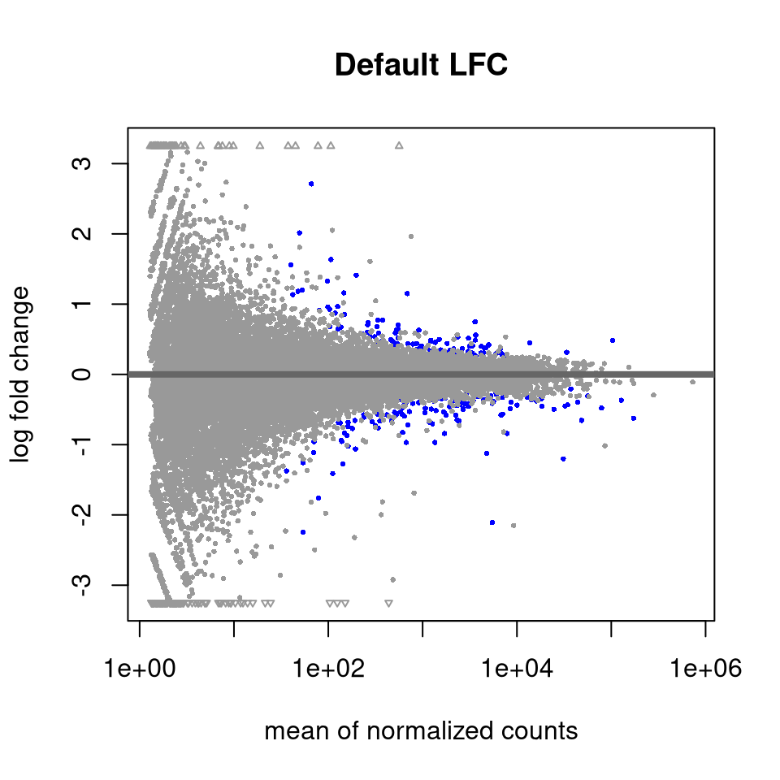

```r
DESeq2::plotMA(res, main="Default LFC")
```

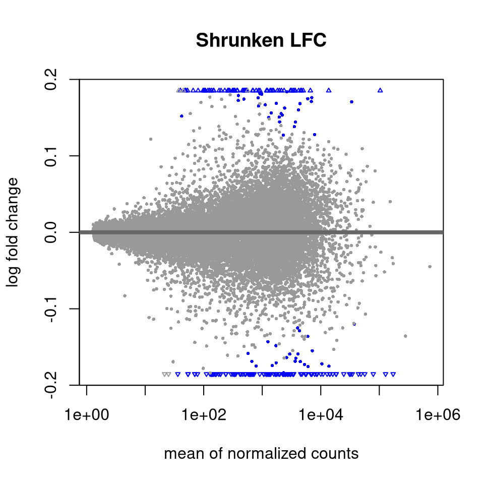

```r
DESeq2::plotMA(lfc_shrink, main="Shrunken LFC")
```

### 1.0.8 **Output DE results**

Here, we merge the different gene name columns to the DE results and output to a tab-delimited file, which can be opened in Excel for manual perusal.

```r
df <- cbind(as.data.frame(rowData(dds)[rownames(lfc_shrink), 1:4]),
            as.data.frame(lfc_shrink)) %>%
  tibble::rownames_to_column("ens_gene")
```

```r
write_tsv(df, file.path(outdir, "de_res.tsv"))
write_rds(df, file.path(outdir, "de_res.rds"))
```

### 1.0.9 **Look for specific genes**

If we’re interested in specific genes (such as genes we’d expect, a priori, to be different), we can check if they are differentially expressed.

The following genes are shown, based on genes specified in the `genes_of_interest` parameter in the config file.

```r
if (!(params$genes_of_interest %in% c("", "False", "FALSE"))) {
  genes_of_interest <- params$genes_of_interest %>% strsplit(",") %>% unlist() %>% gsub("\\s+", "", .)
  df %>% dplyr::filter(Symbol %in% genes_of_interest) %>% print()
}
```

```
##  [1] ens_gene       Symbol         Uniq_syms      entrez         Gene_name
##  [6] baseMean       log2FoldChange lfcSE          pvalue         padj
## <0 rows> (or 0-length row.names)
```

### 1.0.10 **Output tables with raw counts**

Some folks also find it useful to have tables of the raw counts or the normalized counts. The raw counts can be extracted from the DESeq2 object using either `assay()` or `counts()`.

```r
df <- cbind(as.data.frame(rowData(dds)[, 1:4]),
            assay(dds, "counts")) %>%
  tibble::rownames_to_column("ens_gene")
```

```r
write_tsv(df, file.path(outdir, "counts.tsv"))
```

### 1.0.11 **Output tables with log2 normalized counts**

For the log2 normalized counts, we commonly use the variance stabilized transformation ([VST](https://rdrr.io/bioc/DESeq2/man/varianceStabilizingTransformation.html)). These values can be used for heatmaps, clustering or other downstream applications.

```r
vsd <- vst(dds, blind=FALSE)

vst_df <- as.data.frame(cbind(rowData(vsd)[, 1:4], assay(vsd))) %>%
  tibble::rownames_to_column("ens_gene")
```

```r
write_rds(vsd, file.path(outdir, "vsd.rds"))
write_tsv(vst_df, file.path(outdir, "vst.tsv"))
```

## 1.1 **Some common plots for DEG analysis**

### 1.1.1 **Volcano plot**

```r
make_volcano <- function(df, pval_nm, pval_cutoff=0.1){
  # remove genes with NA for pvalue
  df <- df[which(!is.na(df[[pval_nm]])), ]

  # add gene names
  df <- cbind(df, rowData(dds)[rownames(df), 1:4])

  top_genes <- df %>%
    dplyr::arrange(desc(abs(df$log2FoldChange))) %>%
    dplyr::filter(row_number() <= 10) %>%
    rownames()

  df$Sig <- ifelse(df$padj <= pval_cutoff, "Sig", "NS")

  df[[pval_nm]] <- -log10(df[[pval_nm]])


  ggplot(df, aes_string(x="log2FoldChange", y=pval_nm)) +
    geom_point(aes(color=Sig), size=0.6) +
    scale_color_manual(values=c("black", "salmon")) +
    theme_bw() + ylab(str_glue("-log10(", pval_nm,")")) +
    geom_text_repel(data=df[top_genes, ],
                    aes(label=Uniq_syms), max.overlaps=Inf, min.segment.length = 0)
}
```

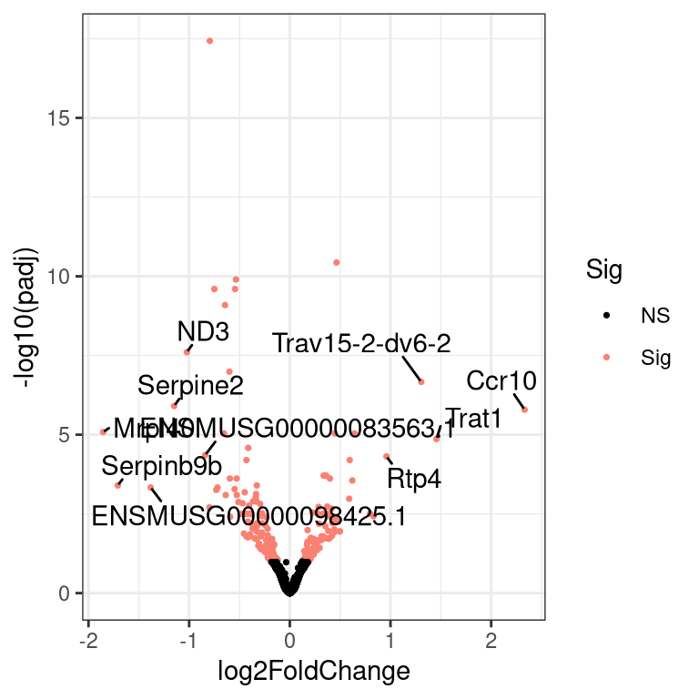

```r
make_volcano(as.data.frame(lfc_shrink),
             pval_nm="padj", pval_cutoff=fdr_cutoff)
```

### 1.1.2 **Heatmap**

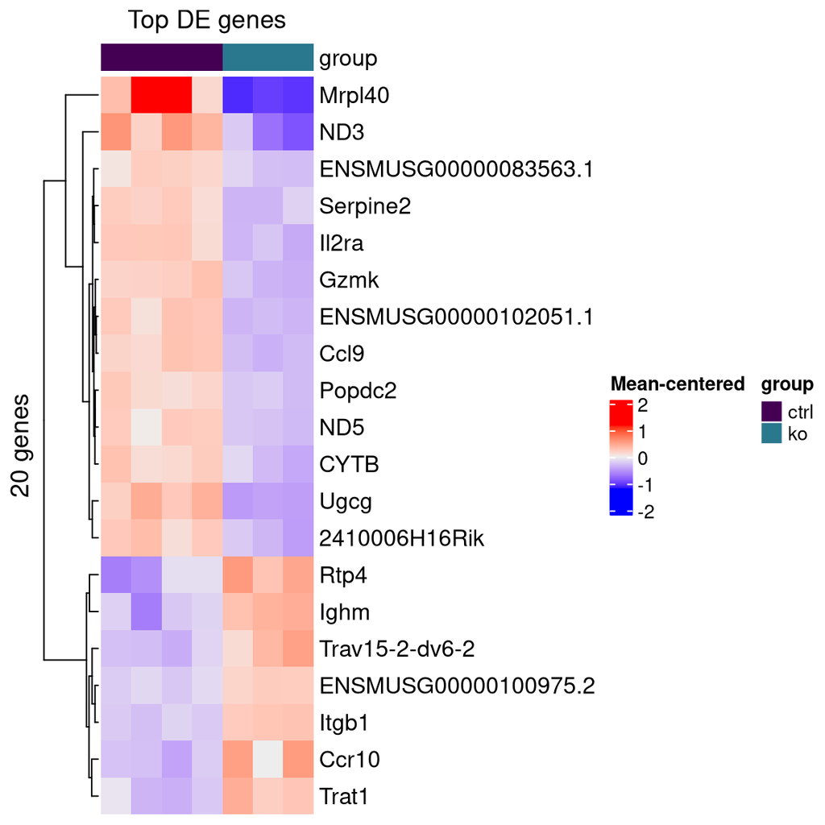

```r
top_genes <- rownames(res)[1:20]

top_se <- se[top_genes, ]
mat <- assay(top_se, "vst")
mat <- t(scale(t(mat), scale=FALSE, center = TRUE))

# column annot
ht_col_annot <- as.data.frame(colData(top_se)[, "group", drop=FALSE])

group_lvls <- unique(ht_col_annot$group)
ht_col_colors <- list(group=setNames(c("#440154FF","#2A788EFF"),
                                         nm=group_lvls))

Heatmap(mat,
        name = "Mean-centered",
        cluster_columns = FALSE,
        row_labels=rowData(top_se)$Uniq_syms,
        show_column_names = FALSE,
        top_annotation=HeatmapAnnotation(df=ht_col_annot,
                                         col=ht_col_colors),
        column_title = "Top DE genes",
        row_title = paste0(nrow(mat), " genes")
)
```

### 1.1.3 **P value distribution**

Ideally, we will see an anti-conservative (if there are many DE genes) or uniform pattern (not many DE genes). See [here](http://varianceexplained.org/statistics/interpreting-pvalue-histogram/) for more details about how to interpret these.

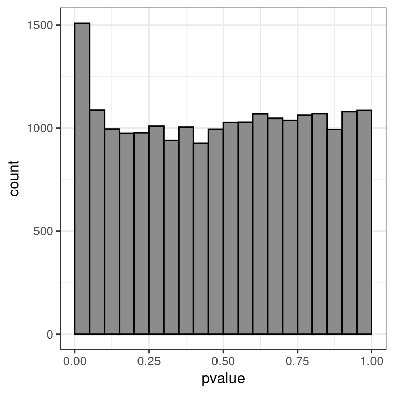

```r
ggplot(data = as.data.frame(lfc_shrink) %>%
         dplyr::filter(!is.na(pvalue)),
       aes(x = pvalue)) +
  geom_histogram(color = "black", fill = "gray55",
                 breaks = seq(0, 1, 0.05)) + theme_bw() + theme(plot.title=element_text(size=10))
```

# 3 Time

```r
# output time taken to run script
end_tm <- Sys.time()
end_tm
```

```
## [1] "2025-02-24 12:36:47 EST"
```

```r
end_tm - start_tm
```

```
## Time difference of 26.66246 secs
```